# Séance de travaux dirigés 5

#### [Questions de cours](http://francoio.github.io/html/CM4.html)

- Rappeler la définition de la [loi de Poisson](https://fr.wikipedia.org/wiki/Loi_de_Poisson) de paramètre $\lambda >0$.
- Rappeler l’espérance de la loi de Poisson.
- Rappeler le théorème de transfert pour une loi discrète.
- Rappeler la formule de conditionnement pour une loi discrète.

#### Exercice 1

Au [football](https://fr.wikipedia.org/wiki/Lois_du_jeu), on peut normalement marquer des buts de la tête ou du pied. On suppose que le nombre de buts marqués lors d’une partie est un nombre aléatoire $K$ tiré suivant la loi de Poisson de paramètre $\lambda >0$.

La probabilité pour qu’un but soit marqué de la tête est $p$, $0 < p < 1$, et on suppose que les buts sont marqués indépendamment les uns des autres.

##### Question 1

- Sachant que $K = k$ buts ont été marqués lors d’une partie, montrer que la probabilité conditionnelle pour que $L = \ell$ buts soient marqués de la tête est
  $${\rm P} (L = \ell ~|~ K = k ) = \frac{k!}{\ell! (k - \ell)!} p^\ell (1 - p)^{k - \ell} , \quad \ell = 0, \dots, k$$

##### Question 2

- En déduire la probabilité que l’on observe $L = \ell$ buts marqués de la tête lors d’une partie.
- Calculer l’espérance de la variable aléatoire $L$.

##### [Les stats de la loose](http://www.lequipe.fr/Football/Actualites/Les-stats-de-la-lose/534110)

On suppose que le [nombre moyen de but marqués](https://fr.wikipedia.org/wiki/Statistiques_et_records_du_championnat_de_France_de_football) par match de football est $\lambda = 2.37$. La probabilité de marquer de la tête est $p = .38$.

- Vérifier que la loi de $L$ correspond au modèle calculé dans la question précédente

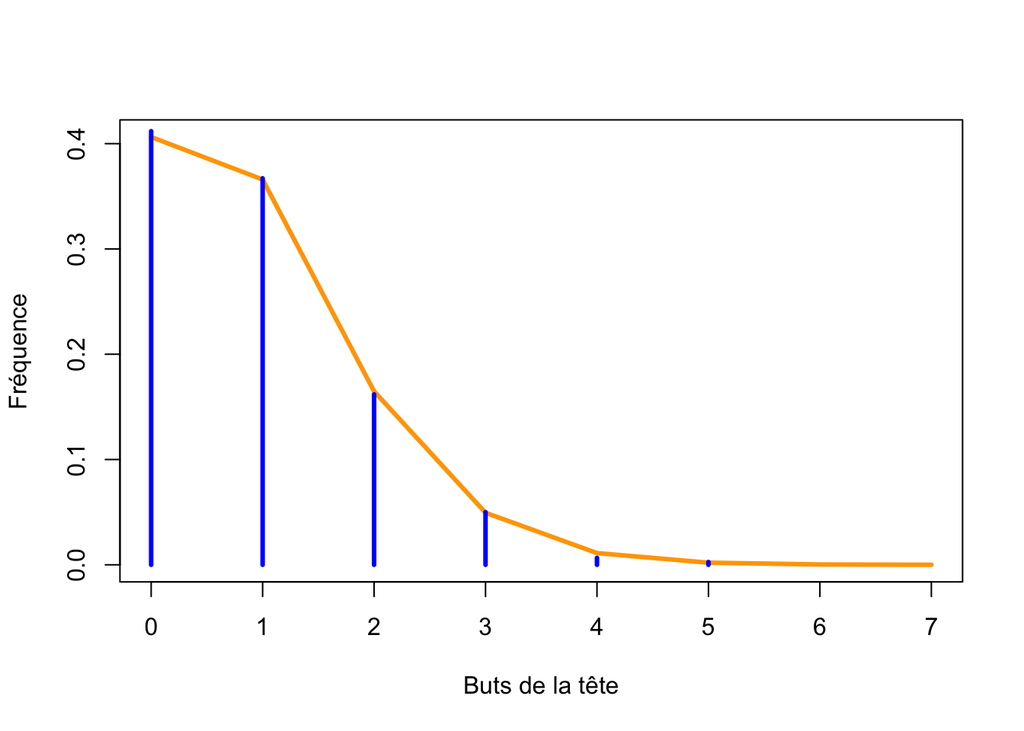

```r
# Il y a 760 matches dans une saison régulière de ligue 1
K <- rpois(760, lambda = 2.37)
L <- rbinom(760, K, p = 0.38)
plot(0:7, dpois(0:7, lambda = 0.38*2.37), xlab = "Buts de la tête", ylab = "Fréquence", col = "orange", lwd = 3, type = "l")
points(table(L)/sum(table(L)), type = "h", col = "blue", lwd = 3)
```

##### Question 3

En fait, le modèle est imparfait et il existe une probabilité $\epsilon>0$ pour qu’un but soit [marqué de la main](https://es.wikipedia.org/wiki/La_mano_de_Dios).

- Quelle est la probabilité d’observer au moins un but marqué de la main lors d’une partie ?

#### Exercice 2

Un [rat](https://fr.wikipedia.org/wiki/Rat) se trouve dans un labyrinthe face à deux portes. Il choisit la première de ces deux portes avec probabilité 1/3 et la deuxième porte avec probabilité 2/3. Quand il choisit la première porte, il revient à son point de départ en une minute. Quand il choisit la deuxième porte, il effectue un trajet d’une minute jusqu’à un point intermédiaire, puis il rebrousse chemin avec la probabilité 1/2 (le retour lui prend alors une minute) ou il sort du labyrinthe en une minute avec la probabilité 1/2. Tous les choix du rat se font indépendamment les uns des autres.

Soit $T$ le temps passé par le rat dans le labyrinthe. On cherche à déterminer l’espérance de $T$, puis la loi de $T$.

##### Question 1

Soit $N$ le numéro de la porte choisie au départ du rat.

- Etablir une relation simple reliant E$[T|N=1]$ et E$[T]$.
- Etablir une relation similaire reliant E$[T|N=2]$ et E$[T]$.
- Appliquer la formule de conditionnement et en déduire la valeur de E$[T]$.

##### Question 2

On note $d, i$ et $s$ les points de départ, intermédiaire et de sortie du rat, et on note $X_n$ la suite aléatoire des points visités par le rat.

- Trouver la relation entre la loi de $T$ et les probabilités conditionnelles suivantes

$$p_{ds}^n = {\rm P}(X_n = s|X_0=d), \quad n \geq 0.$$

- Montrer par récurrence que l’on a la relation suivante

$$p_{ds}^{n+1} = \frac13 ( p_{ds}^{n} + p_{ds}^{n-1} + 1).$$

- Résoudre cette équation et en déduire la loi de $T$. Retrouver l’espérance de $T$ par le calcul direct.